# Model Diagnostics

## Model Diagnostic Plots

These model diagnostic plots assess whether the chains of our models are converged and well mixed, and if the model is well specified and has an adequate fit.

The first plot of the series shows trace plots for each of our parameters, where we want to see stationary and well-mixed chains. The second plot shows an autocorrelation plot by chain and parameter. We want our autocorrelation to quickly drop to zero with increasing lag. Next we have a visual inspection of $\hat{R}$ values. If chains are at equilibrium and have converged to a common distribution values, $\hat{R}$ will be 1. We also visually inspect $n_{eff}$ ratio, which indicates if the draws of the Markov chain are behaving independently. If there is autocorrelation, $n_{eff}$ is usually smaller than the total sample size N, so the larger the ratio of $n_{eff}$ to N, the better (if the ratio is less than 0.1 that indicates a problem). Finally, we have the posterior predictive check where we want the black line to be within/close to the blue lines, to indicate that our model is adequately generative.

## Model 1: Vander-Vennen Paper

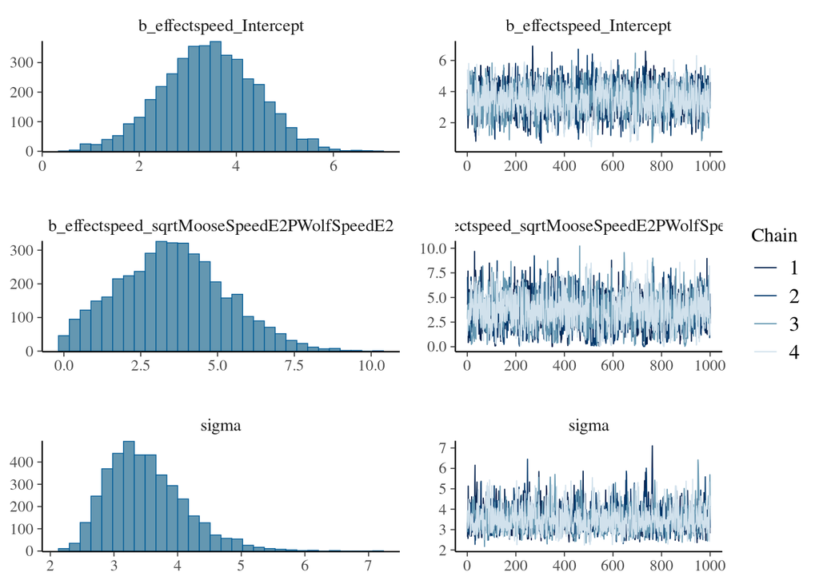

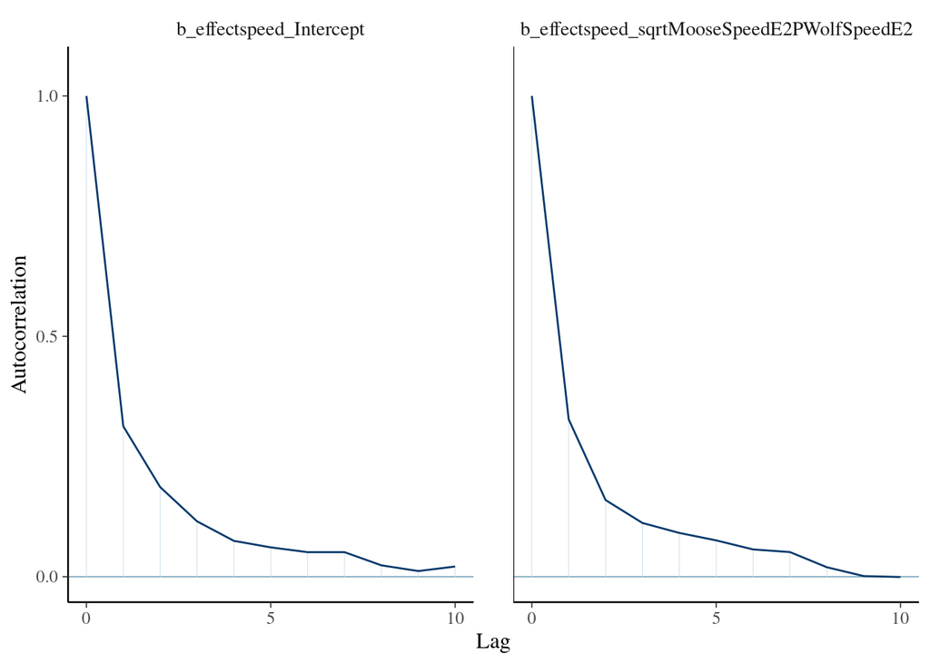

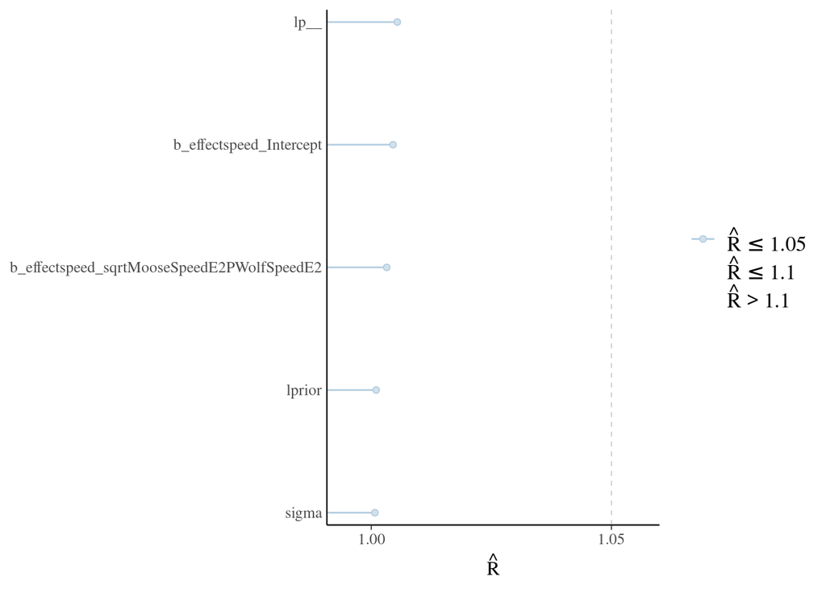

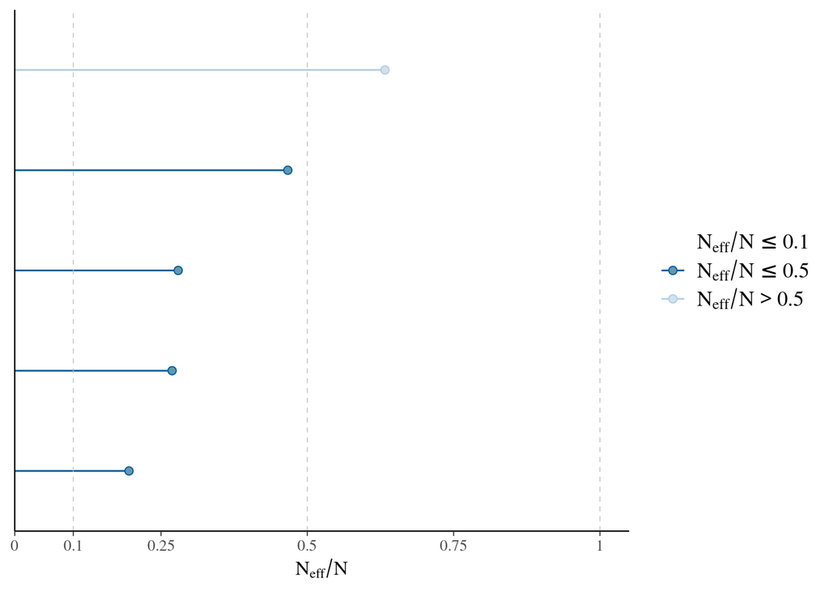

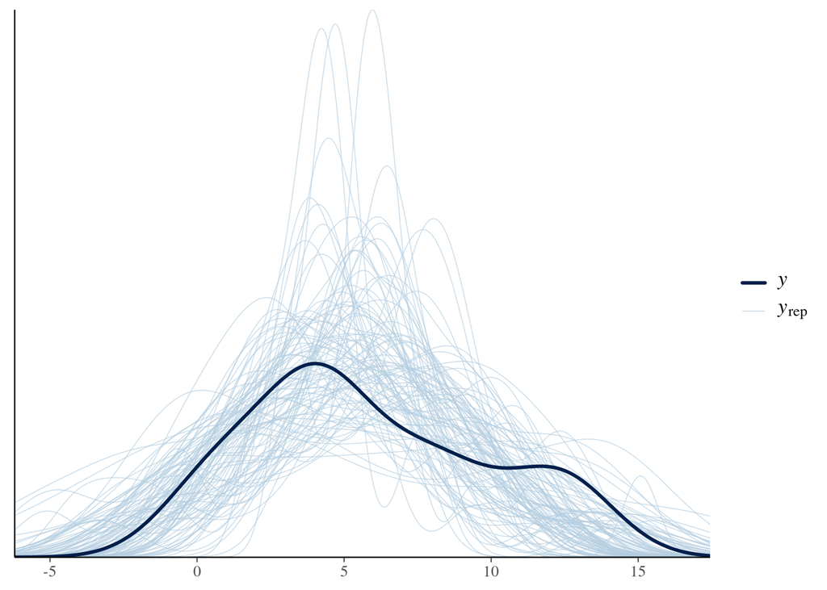